# Boruta Feature Selection in R

## Description

Boruta 알고리즘은 랜덤포레스트를 기반으로 변수를 선택하는 래퍼 방법(Wrapper Method)으로 기본적인 아이디어는 기존 변수를 복원추출해서 만든 변수(shadow) 보다 모형 생성에 영향을 주지 못했다고 하면 이는 가치가 크지 않은 변수로 인식하여 제거하는 것이다. Boruta 알고리즘의 절차는 다음과 같다.

**step 1)** 모든 독립변수에 대한 복제한 랜덤 변수를 생성한다. 예를 들어, 원 데이터에 5개 보다 적은 독립 변수가 있을 때, 적어도 5개의 변수를 복제한다. 이를 우리는 “shadow features” or “permuted copies” 라고 부른다.

**step 1)** 반응변수와의 상관을 제거하기 위해 복제된 자료를 랜덤하게 섞고 원 자료와 결합한다.

**step 2)** 결합된 데이터와 원 데이터에 대해 랜덤포레스트 모형을 생성하고, MDA(Mean Decrease Accuracy)와 같은 변수중요도를 계산한다.

**step 3)** 그런 다음, Z-score를 계산하는데 이는 변수마다 [(각 트리에 대한 정확도 손실 값 - 전체 트리의 정확도 손실의 평균) / 정확도 손실 표준편차]로 나눈 값이다. $z = (x-\mu)/\sigma$

**step 4)** 쉐도우 변수들 중 가장 높은 Z-score(MZSA, Maximum Z score among Shadow Attributes)를 찾는다.

**step 5)** 원 자료에 대한 Z-score가 MZSA보다 큰 경우 Hit를 +1 해준다. (이는 MZSA보다 클때 중요한 변수를 표시하는 수단)

**step 6)** 위의 6번 과정을 랜덤포레스트가 수행되는 횟수만큼 또는 모든 변수들이 중요한 변수와 중요하지 않은 변수로 tagged 될 때까지 반복한다.

Boruta 알고리즘을 수행한 결과, 변수는 보통 rejected/confirmed 라는 결론이 나오는데 이는 변수가 중요한 변수로 판단되기까지 과정을 통해 나타나는 결과이다. step 6에서 원 변수의 Z-score가 MZSA 값에 따라 hit or unhit로 나뉘는데 이는 p=0.5인 확률실험을 하는 것으로 이해할 수있다. 이를 n번 반복하므로 Z-score는 Binom(n,0.5)인 분포를 따른다고 할 수 있다. 또한, 우리는 이러한 정보를 가지고 모비율 검정을 수행할 수 있으며 hit 수가 클수록 p가 크기 때문에 중요한 변수로 판단된다. 이때, 검정을 n번 수행하게 되므로 다중검정임을 유의하자.

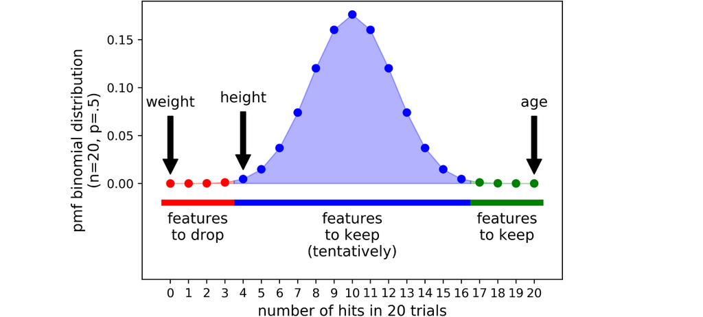

위의 그림에서 red 영역은 변수가 중요하다고 판단되지 않은 영역으로 생각할 수 있다. blue영역에 속한 변수는 판단하기 어려운 변수로 생각할 수 있으며 다른 방안으로 결론을 내릴 수 있다. green 영역은 기각역($\alpha = 0.05$)으로 변수가 중요하다고 판단된다.

Boruta 알고리즘을 더 자세히 공부하고 싶다면 eeyem 블로그의 [Boruta 알고리즘](https://syj9700.tistory.com/50)을 읽어보자. 이제 R을 이용하여 Boruta 알고리즘에 대해 실습하고 결과를 해석해볼 것이다. 실습 과정의 절차와 사용된 데이터는 [tutorial](https://www.analyticsvidhya.com/blog/2016/03/select-important-variables-boruta-package/) 포스팅을 참고하여 수행되었다.

## Boruta in r

```r
library(Boruta)
library(readr)
library(tidyverse)
traindata <- read_csv("G:/Master/project/Boruta_train.csv")
summary(traindata)
```

```
##    Loan_ID             Gender            Married           Dependents
##  Length:614         Length:614         Length:614         Length:614
##  Class :character   Class :character   Class :character   Class :character
##  Mode  :character   Mode  :character   Mode  :character   Mode  :character
##
##
##
##
##   Education         Self_Employed      ApplicantIncome CoapplicantIncome
##  Length:614         Length:614         Min.   :  150   Min.   :    0
##  Class :character   Class :character   1st Qu.: 2878   1st Qu.:    0
##  Mode  :character   Mode  :character   Median : 3812   Median : 1188
##                                        Mean   : 5403   Mean   : 1621
##                                        3rd Qu.: 5795   3rd Qu.: 2297
##                                        Max.   :81000   Max.   :41667
##
##    LoanAmount    Loan_Amount_Term Credit_History   Property_Area
##  Min.   :  9.0   Min.   : 12      Min.   :0.0000   Length:614
##  1st Qu.:100.0   1st Qu.:360      1st Qu.:1.0000   Class :character
##  Median :128.0   Median :360      Median :1.0000   Mode  :character
##  Mean   :146.4   Mean   :342      Mean   :0.8422
##  3rd Qu.:168.0   3rd Qu.:360      3rd Qu.:1.0000
##  Max.   :700.0   Max.   :480      Max.   :1.0000
##  NA's   :22      NA's   :14       NA's   :50
##  Loan_Status
##  Length:614
##  Class :character
##  Mode  :character
##
##
##
##
```

```r
names(traindata) <- gsub("_", "", names(traindata))
```

- 전처리의 편의를 위하여 변수명을 교체해준다.
- gsub 함수는 특정 문자를 다른 형태로 대체해주는 함수이다. 여기서는 "_" 문자를 공백으로 바꿔주었다.

```r
traindata[which(is.na(traindata)),]  # NA 값 위치 확인
```

```
## # A tibble: 149 x 13
##    LoanID Gender Married Dependents Education SelfEmployed ApplicantIncome
##    <chr>  <chr>  <chr>   <chr>      <chr>     <chr>                  <dbl>
##  1 <NA>   <NA>   <NA>    <NA>       <NA>      <NA>                      NA
##  2 <NA>   <NA>   <NA>    <NA>       <NA>      <NA>                      NA
##  3 <NA>   <NA>   <NA>    <NA>       <NA>      <NA>                      NA
##  4 <NA>   <NA>   <NA>    <NA>       <NA>      <NA>                      NA
##  5 <NA>   <NA>   <NA>    <NA>       <NA>      <NA>                      NA
##  6 <NA>   <NA>   <NA>    <NA>       <NA>      <NA>                      NA
##  7 <NA>   <NA>   <NA>    <NA>       <NA>      <NA>                      NA
##  8 <NA>   <NA>   <NA>    <NA>       <NA>      <NA>                      NA
##  9 <NA>   <NA>   <NA>    <NA>       <NA>      <NA>                      NA
## 10 <NA>   <NA>   <NA>    <NA>       <NA>      <NA>                      NA
## # ... with 139 more rows, and 6 more variables: CoapplicantIncome <dbl>,
## #   LoanAmount <dbl>, LoanAmountTerm <dbl>, CreditHistory <dbl>,
## #   PropertyArea <chr>, LoanStatus <chr>
```

```r
traindata[traindata == ""] <- NA  # blank 값 확인
```

- 많은 변수들이 NA결측값을 가지고 있으며, NA로 인식되지 않은 공백이 있는지 확인한다. 공백이 있다면 NA값으로 처리한다.

```r
traindata <- traindata[complete.cases(traindata),]
```

- 편의를 위해 가장 심플한 방법으로 결측값을 모두 삭제해준다.

```r
convert <- c(2:6, 11:13)
traindata[,convert] <- lapply(traindata[,convert], factor)
```

```r
print(boruta.train)
```

[output not shown]

```
## Boruta performed 99 iterations in 7.230635 secs.
##  5 attributes confirmed important: ApplicantIncome, CoapplicantIncome,
## CreditHistory, LoanAmount, LoanAmountTerm;
##  4 attributes confirmed unimportant: Dependents, Education, Gender,
## SelfEmployed;
##  2 tentative attributes left: Married, PropertyArea;
```

- Boruta 알고리즘을 수행한 결과, LoanID 변수를 제외한 11개의 변수 중 5개의 변수가 important(confirmed), 4개의 변수가 unimportant(rejected), 2개의 변수가 tentative 변수로 선택되었다.
- tentative 변수(잠정적인 변수)는 중요도가 가장 높은 shadow 변수(NSZA)에 매우 가깝기 때문에 알고리즘을 수행한 횟수(defalut = 100)로는 신뢰도에 대한 결정을 내릴 수 없는 변수이다.
- Boruta 알고리즘을 수행한 결과를 시각화할 수 있다.

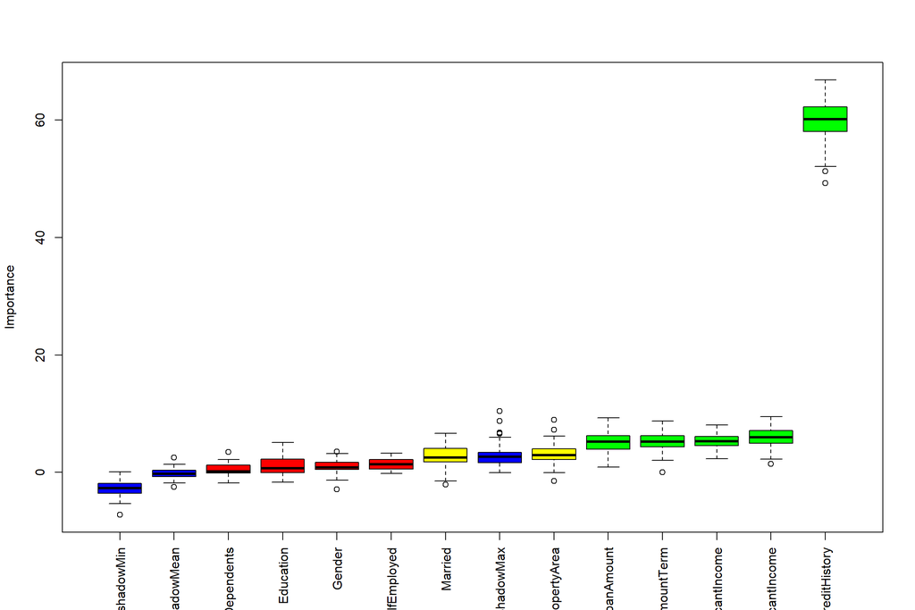

```r
plot(boruta.train, xlab = "", xaxt = "n")
lz<-lapply(1:ncol(boruta.train$ImpHistory),function(i)
    boruta.train$ImpHistory[is.finite(boruta.train$ImpHistory[,i]),i])
names(lz) <- colnames(boruta.train$ImpHistory)
Labels <- sort(sapply(lz,median))
axis(side = 1,las=2,labels = names(Labels),
       at = 1:ncol(boruta.train$ImpHistory), cex.axis = 1)
```

- blue 박스플랏은 쉐도우 변수에 대한 Z-score의 최소, 최대, 평균값에 해당한다.
- red, yellow, green 박스플랏은 각각 기각된 변수, 잠정적인 변수, 채택된 변수의 Z-score을 나타낸다.

```r
final.boruta <- TentativeRoughFix(boruta.train)
print(final.boruta)
```

```
## Boruta performed 99 iterations in 7.230635 secs.
## Tentatives roughfixed over the last 99 iterations.
##  6 attributes confirmed important: ApplicantIncome, CoapplicantIncome,
## CreditHistory, LoanAmount, LoanAmountTerm and 1 more;
##  5 attributes confirmed unimportant: Dependents, Education, Gender,
## PropertyArea, SelfEmployed;
```

- tentative 변수에 대한 중요성을 결정하기 위해 TentativeRoughFix 함수를 사용한다.
- TentativeRoughFix 함수는 boruta의 실행횟수가 적거나 shadow 변수를 생성하는데 있어서 운이 좋지 않았거나, 다소 까다로운 데이터 셋의 경우에 tentative 변수를 남길 수 있는데 각 tentative 변수에 대한 판단을 위해 간단한 검정을 수행하는 것이다.

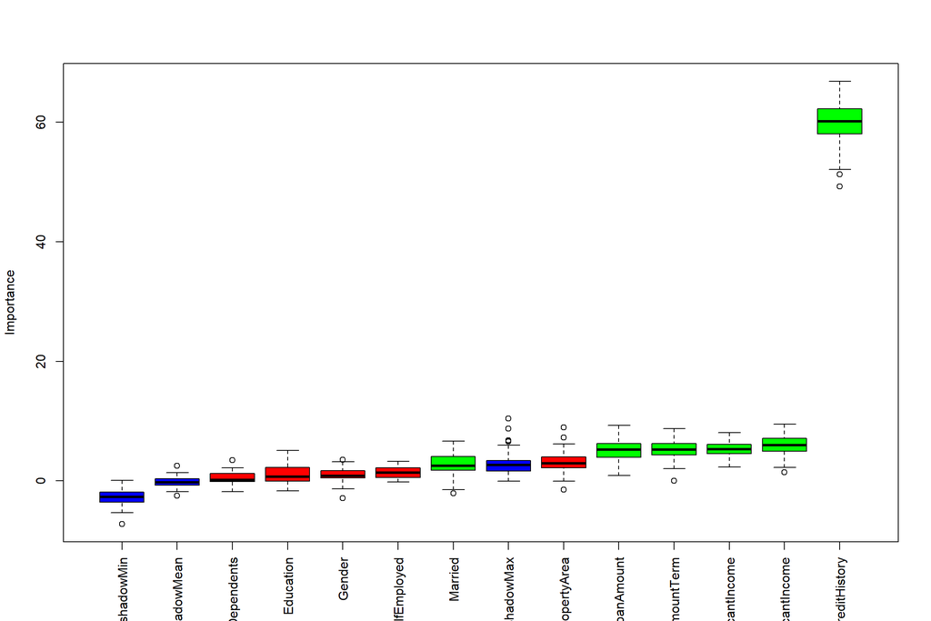

```r
plot(final.boruta, xlab = "", xaxt = "n")
lz<-lapply(1:ncol(final.boruta$ImpHistory),function(i)
    final.boruta$ImpHistory[is.finite(final.boruta$ImpHistory[,i]),i])
names(lz) <- colnames(final.boruta$ImpHistory)
Labels <- sort(sapply(lz,median))
axis(side = 1,las=2,labels = names(Labels),
       at = 1:ncol(final.boruta$ImpHistory), cex.axis = 1)
```

```r
getSelectedAttributes(final.boruta, withTentative = F)
```

```
## [1] "Married"           "ApplicantIncome"   "CoapplicantIncome"
## [4] "LoanAmount"        "LoanAmountTerm"    "CreditHistory"
```

- 최종적으로 중요하다고 판단된 변수는 6개이다.
- attStats함수는 boruta 알고리즘의 결과를 데이터 프레임으로 만들어주며, 각 변수에 대한 중요도와 hits 수, 판단 결과를 생성한다.

```r
boruta.df <- attStats(final.boruta)
class(boruta.df)
```

```
## [1] "data.frame"
```

```r
print(boruta.df)
```

```
##                      meanImp  medianImp      minImp    maxImp   normHits
## Gender             0.8574126  0.8325756 -2.88426998  3.564537 0.04040404
## Married            2.8571819  2.5530202 -2.04974714  6.688518 0.52525253
## Dependents         0.4914849  0.1694371 -1.80043321  3.499246 0.01010101
## Education          1.0793203  0.7037899 -1.68657040  5.082514 0.09090909
## SelfEmployed       1.3613668  1.3733028 -0.19126386  3.306368 0.08080808
## ApplicantIncome    6.0041821  5.9942150  1.47213778  9.511199 0.88888889
## CoapplicantIncome  5.3048565  5.2832790  2.30195773  8.106116 0.88888889
## LoanAmount         5.1043228  5.2352910  0.88248784  9.291136 0.87878788
## LoanAmountTerm     5.3195400  5.2397498  0.03101652  8.757503 0.84848485
## CreditHistory     59.7318750 60.1930448 49.24276863 66.873645 1.00000000
## PropertyArea       3.1037657  2.9569216 -1.44255818  8.925524 0.62626263
##                    decision
## Gender             Rejected
## Married           Confirmed
## Dependents         Rejected
## Education          Rejected
## SelfEmployed       Rejected
## ApplicantIncome   Confirmed
## CoapplicantIncome Confirmed
## LoanAmount        Confirmed
## LoanAmountTerm    Confirmed
## CreditHistory     Confirmed
## PropertyArea       Rejected
```

## Advantage of boruta

- boruta 알고리즘은 많은 모수를 튜닝하거나 기억할필요가 없기 때문에 사용하기 쉽우며, 목적이 분류/회귀에 상관없이 적용가능하다.
- 하지만, boruta 알고리즘을 적용하기 위해서는 결측값이 존재해서는 안된다.